# Analyses on Fuel-Related Aircraft Accidents

This project seeks to identify the factors most relevant to fuel-related aircraft accidents. In doing so, models will be created to predict if an accident is fuel-related based on a collection of features.

1. Initial Setup
   1. Using PYODBC to Read the Access File
      1. Variables to be Used
   2. Queries and Conversion to Pandas
   3. Conversion to PySpark
2. Creating New Variables
3. Data Exploration and Cleansing
   1. Fuel/Engine Variables
   2. Numeric Variables
      1. Binary Variables
      2. Continuous Variables
   3. Categorical Variables
4. Word Clouds
5. Predictive Modeling
   1. Model Setup
   2. Model Results

## Initial Setup

PySpark and Pandas will be used for the bulk of the project. However, there is no way to open the Microsoft Access file in either. 'pyodbc' is a module that enables the use of the .mdb file the data is in. \ \ There is no way to convert directly from pyodbc to PySpark, so Pandas will be used as an intermediate stage where the querying of the database will also occur.

#### Using PYODBC to Read the Access File

```python
# Connecting to the MS Access Database using PYODBC in Python
!pip install pyodbc
import pyodbc
[x for x in pyodbc.drivers() if x.startswith('Microsoft Access Driver')]
conn_str = (
    r'DRIVER={Microsoft Access Driver (*.mdb, *.accdb)};'
    r'DBQ=C:\Users\jamrh\avall.mdb;'
    )
cnxn = pyodbc.connect(conn_str)
cursor = cnxn.cursor()
```

We can now see the tables present in the Access database.

```python
print('Tables in Dataset:')
for info in cursor.tables(tableType='TABLE'):
    print(info.table_name)
```

```
Tables in Dataset:
aircraft
Country
ct_iaids
ct_seqevt
dt_aircraft
dt_events
dt_Flight_Crew
eADMSPUB_DataDictionary
engines
events
Events_Sequence
Findings
Flight_Crew
flight_time
injury
narratives
NTSB_Admin
Occurrences
seq_of_events
states
```

#### Variables to be Used

The following table includes all potentially relevant variables in the dataset. Some will be used for filtering, some will be used for modeling, and others to create entirely new variables.

```python
%%html
<style>
table {float:left}
</style>
```

|  | **Variable** | Description </b> | Example(s) |
| --- | --- | --- | --- |
| 1 | ev_id | Unique ID for each event, present in all relevant tables | 20080107X00026 |
|  | *'events' table* |  |  |
| 2 | ev_type | Type of event (classified by severity; accident is more serious) | INC, ACC |
| 3 | ev_state | State in which the event occurred (includes U.S. territories) | MD, DC, PR |
| 4 | ev_country | Country in which the event occurred | USA |
| 5 | latitude | Latitude of the event | 381326N |
| 6 | longitude | Longitude of the event | 1222659W |
| 7 | ev_highest_injury | Highest level of injury | MINR, FATL |
| 8 | inj_tot_t | Total number of injuries. Includes 'NONE' injuries so it can be a count of people involved | 334 |
| 9 | apt_dist | Distance from airport (in statute miles) | 5 |
| 10 | light_cond | Light conditions | DAYL, DUSK |
| 11 | wx_temp | Air temperature (in degrees celsius) | 37 |
| 12 | wind_vel_kts | Wind speed (in knots) | 11 |
|  | *'aircraft' table* |  |  |
| 13 | acft_category | Aircraft category | AIR, HELI |
| 14 | acft_year | Year of manufacture | 2001 |
| 15 | acft_make | Aircraft manufacturer | Boeing, PIPER |
| 16 | acft_model | Aircraft model | 747-400, R44 II |
| 17 | acft_fire | Indicates occurrence of fire | GRD, IFLT |
| 18 | acft_expl | Indicates occurrence of explosion | GRD, IFLT |
| 19 | far_part | Regulation authority the aircraft was operating under | 091, NUSN |
| 20 | damage | Severity of damage to aircraft | SUBS, DEST |
| 21 | num_eng | Number of engines | 2 |
| 22 | type_fly | Purpose of the flight | PERS, FIRF |
| 23 | site_seeing | Indicates if aircraft was conducting siteseeing operations | N, Y |
| 24 | cert_max_gr_wt | Gross weight of the aircraft, including cargo and passengers | 3400 |
| 25 | homebuilt | Indicates if aircraft is amateur-built | N, Y |
| 26 | afm_hrs | Total airframe operating hours | 670 |
| 27 | afm_hrs_last_insp | Airframe operating hours since last inspection | 48 |
|  | *'engines' table* |  |  |
| 28 | eng_type | Type of engine(s) | TP, REC |
| 29 | eng_mfgr | Engine manufacturer | Lycoming, Williams |
| 30 | eng_model | Engine model | O-360-A1D, 912 |
| 31 | power_units | Engine output (in hp or lbs) | 220, 22100 |
| 32 | hp_or_lbs | Indicates engine power unit of measure | HP, LBS |
| 33 | carb_fuel_injection | For aircraft with reciprocating engines, indicates the fuel system (carburetor or fuel-injected) | CARB, FINJ |
|  | *'Findings' table* |  |  |
| 34 | finding_description | Full description of findings for each occurrence | Personnel issues-Action... |
| 35 | finding_code | Full code describing the occurrence | 0204151045 |
| 36 | category_no | Category of the occurrence (first part of finding_code) | 02 |
| 37 | subcategory_no | Subcategory of the occurrence (second part of finding_code) | 04 |
| 38 | Cause_Factor | Indicates whether the occurrence was the cause or factor in the event | C, F |
|  | *'narratives' table* |  |  |
| 39 | narr_cause | Text summary of the probable cause findings following investigation | Shortly after departure... |

#### Queries and Conversion to Pandas

The 'Findings' table contains codes that describe the problems that occurred in the accidents. However, the table splits each event into multiple occurrences. As a result, each value in the event ID variable, 'ev_id,' is duplicated. This project seeks to look at aircraft accidents as single events. \ \ Therefore, the 'Findings' table will be queried separately, relevant data related to fuel and engines will be identified, and that information will be merged with the main dataset to prevent duplication. As the 'narr_cause' variable from the 'narratives' table also contains data pertinent to this, it will be included in the query as well.

```python
# Queries

query1 = '''SELECT DISTINCT aircraft.ev_id, aircraft.acft_category, events.ev_date, aircraft.acft_make,
           aircraft.acft_model, events.ev_type, events.ev_state, events.ev_country, events.latitude, events.longitude,
           events.ev_highest_injury, events.inj_tot_t, engines.eng_type, engines.eng_mfgr, engines.eng_model,
           engines.power_units, engines.hp_or_lbs, engines.carb_fuel_injection, aircraft.far_part, aircraft.damage,
           aircraft.acft_fire, aircraft.acft_expl, aircraft.num_eng, aircraft.type_fly, aircraft.site_seeing,
           aircraft.acft_year, events.apt_dist, events.light_cond, events.wx_temp, events.wind_vel_kts,
           aircraft.cert_max_gr_wt, aircraft.homebuilt, aircraft.afm_hrs, aircraft.afm_hrs_last_insp, narratives.narr_cause

           FROM (events INNER JOIN (((((aircraft LEFT JOIN dt_aircraft ON (aircraft.Aircraft_Key = dt_aircraft.Aircraft_Key)
           AND (aircraft.ev_id = dt_aircraft.ev_id)) LEFT JOIN engines ON (aircraft.Aircraft_Key = engines.Aircraft_Key)
           AND (aircraft.ev_id = engines.ev_id)) LEFT JOIN Events_Sequence ON (aircraft.Aircraft_Key =
           Events_Sequence.Aircraft_Key) AND (aircraft.ev_id = Events_Sequence.ev_id)) LEFT JOIN Findings ON
           (aircraft.Aircraft_Key = Findings.Aircraft_Key) AND (aircraft.ev_id = Findings.ev_id)) LEFT JOIN narratives ON
           (aircraft.Aircraft_Key = narratives.Aircraft_Key) AND (aircraft.ev_id = narratives.ev_id)) ON events.ev_id =
           aircraft.ev_id) LEFT JOIN dt_events ON events.ev_id = dt_events.ev_id'''

query2 = '''SELECT DISTINCT Findings.ev_id, Findings.finding_description, Findings.finding_code, Findings.category_no,
            Findings.subcategory_no, Findings.section_no, Findings.subsection_no, Findings.modifier_no, Findings.Cause_Factor,
            narratives.narr_cause

            FROM Findings LEFT JOIN narratives ON (Findings.ev_id = narratives.ev_id)'''
```

```python
# Querying while converting from PYODBC to Pandas
import pandas as pd
AVGAS = pd.read_sql(query1, cnxn)
AVFIND = pd.read_sql(query2, cnxn)
```

```python
# Adding conditions
condition = (AVGAS.acft_category == 'AIR') & (AVGAS.ev_country =='USA')
AVGAS = AVGAS[condition]
```

#### Conversion to Pyspark

Before we can convert the dataframes, we set up the Spark session and install Apache Arrow. \ Arrow is required to change the Pandas dataframe to a PySpark dataframe.

```python
from pyspark.sql import SparkSession
spark=SparkSession.builder.appName('AVGASproject').getOrCreate()

!pip install pyarrow==7.0.*
spark.conf.set('spark.sql.execution.arrow.enabled', 'true')

spark
```

**SparkSession - in-memory**

**SparkContext**

[Spark UI](http://LAPTOP-881IJG6C:4040)

**Version**

`v3.2.1`

**Master**

`local[*]`

**AppName**

`AVGASproject`

Then we convert the dataframes.

```python
AVGAS = spark.createDataFrame(AVGAS)
AVFIND = spark.createDataFrame(AVFIND)
```

## Creating New Variables

There are several variables that must be created, as they are essential for visualization and modeling.

|  | **Variable** | Description </b> | Example(s) |
| --- | --- | --- | --- |
| 1 | fuel_rel | Identifies if an event is fuel-related based on codes | 0, 1 |
| 2 | eng_rel | Identifies if an event is engine-related (contains 'fuel_rel') | 0, 1 |
| 3 | fuel_narr | Identifies if the word 'fuel' is mentioned in the 'narr_cause' variable | 0, 1 |
| 4 | fuel_rel_cf | Identifies if any part of the code-based 'fuel_rel' was a cause or factor | 0, 1 |
| 5 | eng_rel_cf | Identifies if any part of the code-based 'eng_rel' was a cause or factor | 0, 1 |
| 6 | fuel_narr_cf | Identifies if any part of the search-based 'fuel_narr' was a cause or factor | 0, 1 |
| 7 | target | Identifies if the event contains a target aircraft/engine | 0, 1 |
| 8 | target_mfgr | Identifies the manufacturer the target belongs to | HAWKER, CESSNA, PIPER, NO |

Ultimately, 'fuel_rel' and 'eng_rel' will be dependent variables in modeling, but each will be relevant in data exploration and analysis.

```python
from pyspark.sql import functions as F
from pyspark.sql.functions import col, isnan, when, count, asc, desc, rpad, rank, sum, lit, trim
from pyspark.ml.feature import Imputer
```

The variables 'fuel_rel' and 'eng_rel' will be developed using the relevant codes in 'finding_code.' \ \ There could be multiple different fuel-related occurrences in an event, or there could be non-fuel-related occurrences in the sequence of an event. If the latter exists, the existence of '0' and '1' values in variable creation will cause duplications of the 'ev_id' variable, which would then cause duplications in joining with the main dataset. Therefore, only '1' values will be added. By separating the variables from the rest in the dataframe, using the 'distinct' and 'na.drop' functions would effectively cause only unique 'ev_id' values to remain as well as the indication set by 'fuel_rel' and 'eng_rel.' '0' values will be added after the join.

```python
AVFIND = AVFIND.withColumn('fuel_rel',
     when(AVFIND.finding_code.contains('010228'), '1') #aircraft systems - fuel system
    .when(AVFIND.finding_code.contains('010573'), '1') #engine fuel and control
    .when(AVFIND.finding_code.contains('01071010'), '1') #fluids/misc hardware - fuel
    .when(AVFIND.finding_code.contains('01071040'), '1') #fluids/misc hardware - fuel additive
    )
```

```python
AVFIND = AVFIND.withColumn('eng_rel',
     when(AVFIND.fuel_rel == '1', '1') #including fuel-related issues
    .when(AVFIND.finding_code.contains('0105'), '1') #aircraft power plant
    .when(AVFIND.finding_code.contains('0107102'), '1') #fluids/misc hardware - oil & coolant
    .when(AVFIND.finding_code.contains('01071045'), '1') #fluids/misc hardware - oil additive
    )
```

Next, the 'fuel_narr' variable will be created. It will check mentions of the word 'fuel' in 'narr_cause' and include accidents tracked by the 'fuel_rel' variable. This way, values of '1' in 'fuel_narr' but not 'fuel_rel' will indicate situations where a problem involving fuel occurred, but they would not be ones tracked by the 'fuel_rel' variable's codes. These may be issues caused by human negligence or some other factor not tracked by the finding codes. Similar to the 'fuel_rel' and 'eng_rel' variables, there will be no '0' values for now.

```python
AVFIND = AVFIND.withColumn('fuel_narr',
     when(AVFIND.narr_cause.contains('fuel'), '1')
    .when(AVFIND.fuel_rel == '1', '1')
    )
```

A similar approach is taken with the 'Cause_Factor' variable. Each observation that has a value of '1' in 'fuel_rel,' 'eng_rel,' and 'fuel_narr' and a 'C' in 'Cause_Factor' (which indicates the occurrence was a cause of the event) receives a '1' value, and the '0' will be imputed after the join

```python
AVFIND = AVFIND.withColumn('fuel_rel_cf',
     when((AVFIND.fuel_rel == '1') & (AVFIND.Cause_Factor == 'C'), '1'))

AVFIND = AVFIND.withColumn('eng_rel_cf',
     when((AVFIND.eng_rel == '1') & (AVFIND.Cause_Factor == 'C'), '1'))

AVFIND = AVFIND.withColumn('fuel_narr_cf',
     when((AVFIND.fuel_narr == '1') & (AVFIND.Cause_Factor == 'C'), '1'))
```

Distinct values are kept and observations with null values are dropped. Due to how we handled the new variables, each of the new dataframes should have unique values in 'ev_id' with no duplicates.

```python
AVFIND_fuel_rel = AVFIND.select(['ev_id', 'fuel_rel']).distinct().na.drop()
AVFIND_eng_rel = AVFIND.select(['ev_id', 'eng_rel']).distinct().na.drop()
AVFIND_fuel_narr = AVFIND.select(['ev_id', 'fuel_narr']).distinct().na.drop()

AVFIND_fuel_rel_cf = AVFIND.select(['ev_id', 'fuel_rel_cf']).distinct().na.drop()
AVFIND_eng_rel_cf = AVFIND.select(['ev_id', 'eng_rel_cf']).distinct().na.drop()
AVFIND_fuel_narr_cf = AVFIND.select(['ev_id', 'fuel_narr_cf']).distinct().na.drop()
```

While not shown in this notebook as it'd take up too much space, each of the above dataframes were tested. None of them have duplicates in 'ev_id,' which means they are ready to be joined with the main dataset without causing issues.

```python
AVGAS = AVGAS.join(AVFIND_fuel_rel, ['ev_id'], 'left')
AVGAS = AVGAS.join(AVFIND_eng_rel, ['ev_id'], 'left')
AVGAS = AVGAS.join(AVFIND_fuel_narr, ['ev_id'], 'left')

AVGAS = AVGAS.join(AVFIND_fuel_rel_cf, ['ev_id'], 'left')
AVGAS = AVGAS.join(AVFIND_eng_rel_cf, ['ev_id'], 'left')
AVGAS = AVGAS.join(AVFIND_fuel_narr_cf, ['ev_id'], 'left')
```

To conclude setting up the above variables, missing values will be filled with '0'.

```python
AVGAS = AVGAS.na.fill('0', ['fuel_rel', 'eng_rel', 'fuel_narr', 'fuel_rel_cf', 'eng_rel_cf', 'fuel_narr_cf'])
AVFIND = AVFIND.na.fill('0', ['fuel_rel', 'eng_rel', 'fuel_narr', 'fuel_rel_cf', 'eng_rel_cf', 'fuel_narr_cf'])
```

The 'target_mfgr' variable can be created using the list of target aircraft models provided by the FAA.

```python
AVGAS = AVGAS.withColumn('acft_model', trim(col('acft_model')))

HAWKER_list = ['S35', 'V35', 'V35A', 'V35B', '35-C33A', 'E33A', '36', 'A36', 'A36TC', 'B36TC', 'F33A', 'G33', 'G36']
CESSNA_list = ['177RG', '172I', '172K', '172L', '172M', '172N', '172P', '172Q', '172R', '172S']
PIPER_list = ['PA-28R-201', 'PA-32RT-300T', 'PA-32R-301T', 'PA32-301T', 'PA-32-301XTC', 'PA-46-350P', 'PA-46R-350T',
              'PA-28-140', 'PA-28-150', 'PA-28-160', 'PA-28-180', 'PA-28S-160', 'PA-28S-180', 'PA-28-151',
              'PA-28-161', 'PA-28-181', 'PA-28-235', 'PA-28-236']

AVGAS = AVGAS.withColumn('target_mfgr',
     when(AVGAS.acft_model.isin(HAWKER_list), 'HAWKER')
    .when(AVGAS.acft_model.isin(CESSNA_list), 'CESSNA')
    .when(AVGAS.acft_model.isin(PIPER_list), 'PIPER')
    .otherwise('NO')
    )
```

The 'target' variable can be created using 'target_mfgr'.

```python
AVGAS = AVGAS.withColumn('target', when(AVGAS.target_mfgr != 'NO', '1').otherwise('0'))
```

## Data Exploration and Cleansing

Each variable potentially relevant for modeling will be explored. As there are many variables, they will be separated based their original tables. A table summarizing observations made in the exploration will be at the end of this section.

```python
from pyspark.sql import types, functions as F
from pyspark.sql.functions import col, isnan, when, count, desc, rpad
from pyspark.ml.feature import Imputer
```

```python
print('Total accidents:', AVGAS.count())
```

```
Total accidents: 17505
```

#### Fuel/Engine Variables

First, we'll take a look at the quantities of fuel-related and engine-related events.

```python
AVGAS.groupBy('fuel_rel').count().sort(desc('count')).show()
print('Fuel-related accidents:',
      round((AVGAS.filter(col('fuel_rel') == '1').count() / AVGAS.count() * 100), 2),
      '% of total accidents')
\
AVGAS.groupBy('eng_rel').count().sort(desc('count')).show()
print('Engine-related accidents:',
      round((AVGAS.filter(col('eng_rel') == '1').count() / AVGAS.count() * 100), 2),
      '% of total accidents')
```

```
+--------+-----+
|fuel_rel|count|
+--------+-----+
|       0|15854|
|       1| 1651|
+--------+-----+

Fuel-related accidents: 9.43 % of total accidents
+-------+-----+
|eng_rel|count|
+-------+-----+
|      0|14435|
|      1| 3070|
+-------+-----+

Engine-related accidents: 17.54 % of total accidents
```

Expanding 'fuel_rel' into 'eng_rel' almost doubles the number of relevant events. Therefore, the number of fuel-related issues and engine-related issues is about the same. The broadening with 'eng_rel' could help with training in a predictive model as there are more observations in the minority classification, but it could also lead to weaker models as the classification is less focused. Regardless, the imbalance in both variables would need to be addressed in modeling. Further understandings of these dependent variables will be learned through their use in analyzing other variables. \ \ Next, we will examine the frequencies at which the causes of events were fuel-related and engine-related.

```python
print('Fuel-related problems:',
      round((AVGAS.filter(col('fuel_rel_cf') == '1').count() / AVGAS.filter(col('fuel_rel') == '1').count() * 100), 2),
      '% were causes of the accidents')

print('Engine-related problems:',
      round((AVGAS.filter(col('eng_rel_cf') == '1').count() / AVGAS.filter(col('eng_rel') == '1').count() * 100), 2),
      '% were causes of the accidents')
```

```
Fuel-related problems: 85.83 % were causes of the accidents
Engine-related problems: 82.83 % were causes of the accidents
```

Engine problems were causes 3% less than fuel problems, despite incorporating fuel problems. This may be a sign that there is a bigger disparity between the two. Therefore, there is a possibility that fuel problems are more likely to be a cause of an accident than engine issues. \ \ Following that, 'fuel_rel' and 'fuel_narr' will be compared. By looking at accidents where fuel is mentioned but isn't an aircraft issue in 'fuel_rel,' we can understand what other types of fuel-related issues occur.

```python
AVGAS.groupBy('fuel_narr').count().sort(desc('count')).show()
print("Number of narratives with fuel mentions not in 'fuel_rel':",
     (AVGAS.filter((col('fuel_narr') == '1') & (col('fuel_rel') == '0')).count()))
```

```
+---------+-----+
|fuel_narr|count|
+---------+-----+
|        0|15702|
|        1| 1803|
+---------+-----+

Number of narratives with fuel mentions not in 'fuel_rel': 152
```

We can pull up these narratives and see what kinds of fuel problems the aircraft had.

```python
AVGAS.select('narr_cause').where((col('fuel_narr') == '1') & (col('fuel_rel') == '0')).distinct().head(10)
```

```
[Row(narr_cause="The pilot's improper fuel planning which resulted in a loss of engine power due to fuel exhaustion."),
 Row(narr_cause="The pilot's failure to maintain control of the aircraft during takeoff. Contributing to the accident was his failure to secure a wing fuel panel prior to departure."),
 Row(narr_cause="The pilot's improper maintenance of the airplane's fuel system, which resulted a loss of power in the left engine due to fuel starvation. Also causal was the pilot's failure to maintain minimum controllable airspeed following the loss of engine power, which resulted in a loss of air…
 Row(narr_cause="The pilot's improper fuel management, which resulted in a loss of engine power due to fuel exhaustion. "),
 Row(narr_cause='A total loss of engine power during cruise flight resulting from the failure of a fuel line. Contributing to the accident was inadequate maintenance inspections that failed to detect the deteriorating fuel line.'),
 Row(narr_cause="The loss of engine power due to fuel exhaustion as a result of the pilot's inadequate in-flight planning/decision."),
 Row(narr_cause="A loss of engine power due to the pilot/owner's improper installation of a new ignition/fuel control system for the engine. Contributing was the unsuitable terrain for a forced landing."),
 Row(narr_cause="Fuel exhaustion due to the pilot's inadequate preflight planning and failure to ensure that adequate fuel was onboard to complete the flight."),
 Row(narr_cause="The pilot's inadequate preflight planning, which resulted in fuel exhaustion and a subsequent total loss of power in both engines during cruise flight. Contributing to the accident was the pilot’s use of prescription and illicit drugs, which likely impaired his judgment."),
 Row(narr_cause="The pilot's improper in-flight decision making and inadequate fuel consumption calculations that resulted in fuel exhaustion.")]
```

Most of the above narratives describe negligence from the pilot. Fuel exhaustion is when an aircraft runs out of fuel, so personnel are at fault for inadequate planning or consumption. \ \ For comparison, we can look at the narrative causes where there were issues with the aircraft, as represented by 'fuel_rel.'

```python
AVGAS.select('narr_cause').where((col('fuel_rel') == '1')).distinct().head(7)
```

```
[Row(narr_cause="The total loss of engine power due to fuel starvation as a result of the pilot's failure to reposition the fuel selector to the main tank. Contributing to the accident was the pilot's failure to properly complete the pre-takeoff checklist."),
 Row(narr_cause="The pilot's inadequate preflight inspection, in which he did not detect that less fuel was on board the airplane than planned, which precipitated a loss of engine power due to fuel exhaustion during initial descent."),
 Row(narr_cause="The pilot's failure to secure the left tank's fuel cap after refueling the airplane, which resulted in a loss of engine power due to fuel exhaustion."),
 Row(narr_cause="The flight instructor's decision to turn the fuel selector to the off position and his delayed remedial actions to restart the engine, which resulted in fuel starvation and a subsequent forced landing."),
 Row(narr_cause='The pilot’s inadequate fuel management, which resulted in a total loss of engine power at low altitude due to fuel exhaustion and a forced landing in a muddy field and subsequent nose-over.\r\n'),
 Row(narr_cause="The pilot's mismanagement of the onboard fuel, which resulted in fuel starvation, a total loss of power to both engines, and a subsequent forced landing. \r\n"),
 Row(narr_cause='The pilot’s improper fuel management, which resulted in fuel starvation.\r\n\r\n')]
```

Interestingly, many of the above narratives also depict negligence and fuel exhaustion. As a result, it is likely that issues from negligence caused some of the fuel problems that are recorded by 'fuel_rel'. As negligence was the major cause, perhaps filtering the above by checking only instances where the issues in 'fuel_rel' were the cause might remove the personnel errors. However, it may be unlikely as about 85.83% of accidents with fuel problems considered the fuel problems as causes.

```python
AVGAS.select('narr_cause').where((col('fuel_rel') == '1') & (col('fuel_rel_cf') == '1')).distinct().head(7)
```

```
[Row(narr_cause="The total loss of engine power due to fuel starvation as a result of the pilot's failure to reposition the fuel selector to the main tank. Contributing to the accident was the pilot's failure to properly complete the pre-takeoff checklist."),
 Row(narr_cause="The pilot's inadequate preflight inspection, in which he did not detect that less fuel was on board the airplane than planned, which precipitated a loss of engine power due to fuel exhaustion during initial descent."),
 Row(narr_cause="The pilot's failure to secure the left tank's fuel cap after refueling the airplane, which resulted in a loss of engine power due to fuel exhaustion."),
 Row(narr_cause="The flight instructor's decision to turn the fuel selector to the off position and his delayed remedial actions to restart the engine, which resulted in fuel starvation and a subsequent forced landing."),
 Row(narr_cause='The pilot’s inadequate fuel management, which resulted in a total loss of engine power at low altitude due to fuel exhaustion and a forced landing in a muddy field and subsequent nose-over.\r\n'),
 Row(narr_cause='The pilot’s improper fuel management, which resulted in fuel starvation.\r\n\r\n'),
 Row(narr_cause="A loss of engine power due to fuel exhaustion as a result of the pilot's inadequate fuel planning.")]
```

These results indicate that a finding being considered a cause does not mean that it was the starting issue. Causes may instead mean significant problem points that directly lead to the accidents. Minor affairs in an overarching accident event may not have the severity to be considered causes, only factors. \ \ To further understand the types of fuel-related accidents, we can look at each occurrence and how they are classified. 'fuel_narr' from the findings dataframe, 'AVFIND,' will be looked at, as it is the variable that encompasses the widest variety of fuel-related data by including the codes represented in 'fuel_rel' and observations with mentions of 'fuel' in 'narr_cause.'

```python
AVFIND = AVFIND.withColumn('fuel_narr', AVFIND.fuel_narr.cast('integer'))
AVFIND.groupBy('category_no').sum('fuel_narr').show()
```

```
+-----------+--------------+
|category_no|sum(fuel_narr)|
+-----------+--------------+
|         01|          2909|
|         05|            60|
|         03|           535|
|         02|          2225|
|         04|            84|
+-----------+--------------+
```

A table was created based on the information:

| **'category_no'** | Meaning | Count | Percent</b> |
| --- | --- | --- | --- |
| 01 | Aircraft Issues | 2909 | 50.0% |
| 02 | Personnel Issues | 2225 | 38.3% |
| 03 | Environmental Issues | 535 | 9.2% |
| 04 | Organizational Issues | 84 | 1.4% |
| 05 | Not Determined | 60 | 1.0% |

Aircraft issues only account for 50% of all the fuel-based findings in every event. Even within the 50%, many of those technical problems were caused by personnel issues leading to fuel exhaustion. Adjusting the data to remove all instances of problems caused by fuel exhaustion would be a monumental task, and there may not even be enough data remaining to build an effective model. As a result, using 'fuel_rel' and 'eng_rel' as dependent variables would likely lead to predicting for fuel exhaustion. There may be benefits to that, however, as there may be some variable values that may be correlated with aircraft suffering from that complication.

#### Binary Variables

Before looking at the numeric features, there are several categorical variables that can be transformed into binary numeric variables. This will help with modeling, as the 'scikit-learn' package that will be used for modeling requires that features only contain values of '0' and '1'. While dummy variables can be created for both of these variables' values, making the values '0' and '1' ahead of time will reduce the number of features in modeling, making modeling easier. \ \ For example, 'ev_type,' which only has the values 'INC' and 'ACC,' would become 'ev_type_INC' and 'ev_type_ACC' when converted into dummies when it can just remain 'ev_type' if 'INC' and 'ACC' are turned into '0' and '1.' The below table contains the variables that will be adjusted in this way.

|  | **Variable** | Description </b> | Values to Become 0, 1 |
| --- | --- | --- | --- |
| 1 | ev_type | Type of event (classified by severity; accident is more serious) | INC, ACC |
| 2 | site_seeing | Indicates if aircraft was conducting siteseeing operations | N, Y |
| 3 | homebuilt | Indicates if aircraft is amateur-built | N, Y |
| 4 | hp_or_lbs | Indicates engine power unit of measure | HP, LBS |
| 5 | carb_fuel_injection | For aircraft with reciprocating engines, indicates the fuel system (carburetor or fuel-injected) | CARB, FINJ |

```python
AVGAS = AVGAS.withColumn('ev_type',
     when(AVGAS.ev_type == 'INC', '0')
    .when(AVGAS.ev_type == 'ACC', '1'))

AVGAS = AVGAS.withColumn('site_seeing',
     when(AVGAS.site_seeing == 'N', '0')
    .when(AVGAS.site_seeing == 'Y', '1'))

AVGAS = AVGAS.withColumn('homebuilt',
     when(AVGAS.homebuilt == 'N', '0')
    .when(AVGAS.homebuilt == 'Y', '1'))

AVGAS = AVGAS.withColumn('hp_or_lbs',
     when(AVGAS.hp_or_lbs == 'HP', '0')
    .when(AVGAS.hp_or_lbs == 'LBS', '1'))

AVGAS = AVGAS.withColumn('carb_fuel_injection',
     when(AVGAS.carb_fuel_injection == 'CARB', '0')
    .when(AVGAS.carb_fuel_injection == 'FINJ', '1'))
```

With the binary variables prepared, histograms can be created to understand their distributions.

```python
binary_vars = ['fuel_rel', 'eng_rel', 'target', 'ev_type', 'site_seeing', 'homebuilt',
               'hp_or_lbs', 'carb_fuel_injection']

for column in binary_vars:
    AVGAS = AVGAS.withColumn(column, col(column).cast('integer'))

AVGAS_binary = AVGAS.select(*binary_vars)
```

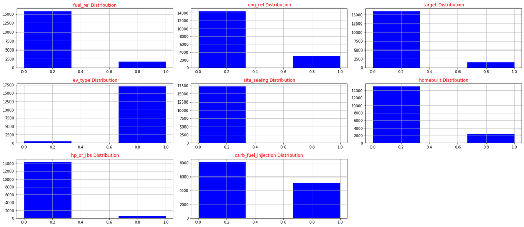

```python
import matplotlib.pyplot as plt
%matplotlib inline

def draw_histograms(dataframe, features, rows, cols):
    fig = plt.figure(figsize=(20, 20))
    for i, feature in enumerate(features):
        ax = fig.add_subplot(rows,cols,i+1)
        dataframe[feature].hist(bins = 3, ax = ax, facecolor = 'blue')
        ax.set_title(feature + " Distribution", color='red')
    fig.tight_layout()
    plt.show()

draw_histograms(AVGAS_binary.toPandas(), AVGAS_binary.toPandas().columns, 7, 3)
```

All of the binary variables are imbalanced. The number of target aircraft is very small relative to every aircraft. The target is meant to be a very small portion of overall aircraft for initial testing, so this makes sense. Almost all of the event types are accidents and not incidents, indicating that nearly all aircraft suffered damage or an amount of people were injured. While 'site_seeing' could have been interesting in indicating a type of flight, it appears nearly useless. Most aircraft are not homebuilt, but over 2,000 of about 17,000 are. The engine power for most aircraft is recorded in horsepower. While still imbalanced, 'carb_fuel_injection' is the most balanced of the above variables, but there are more fuel systems with carburetor rather than fuel injection.

Next, we will check missing values in the variables. Because these variables are binary, they will be imputed with the mode. Due to how 'fuel_rel', 'eng_rel', and 'target' were created, they do not have any missing values.

```python
print('Missing values percentages:')
print('ev_type:', round((AVGAS.filter(col('ev_type').isNull()).count() / AVGAS.count() * 100), 2), '%')
print('site_seeing:', round((AVGAS.filter(col('site_seeing').isNull()).count() / AVGAS.count() * 100), 2), '%')
print('homebuilt:', round((AVGAS.filter(col('homebuilt').isNull()).count() / AVGAS.count() * 100), 2), '%')
print('hp_or_lbs:', round((AVGAS.filter(col('hp_or_lbs').isNull()).count() / AVGAS.count() * 100), 2), '%')
print('carb_fuel_injection:', round((AVGAS.filter(col('carb_fuel_injection').isNull()).count() / AVGAS.count() * 100), 2), '%')
```

```
Missing values percentages:
ev_type: 0.0 %
site_seeing: 1.2 %
homebuilt: 0.0 %
hp_or_lbs: 14.33 %
carb_fuel_injection: 24.51 %
```

Three binary variables have missing data. 'site_seeing', 'carb_fuel_injection', and 'hp_or_lbs' will be imputed with their modes. While about 25% of 'carb_fuel_injection' is missing values, carburetor is the dominant fuel system, so the empty spots will be filled with that.

```python
AVGAS = AVGAS.na.fill(value = 0, subset = 'site_seeing')
AVGAS = AVGAS.na.fill(value = 0, subset = 'carb_fuel_injection')
AVGAS = AVGAS.na.fill(value = 0, subset = 'hp_or_lbs')
```

#### Continuous Variables

Before histograms can be for the continuous variables, an adjustment needs to be made.

For clarity, the 'inj_tot_t' will be changed. It is the sum of all the types of injuries, but it also includes the injury status 'NONE'. As a result, the variable includes all involved people. As a result, the 'inj_tot_t' variable will be renamed to 'sum_people' and can serve as an indication of the number of people onboard an aircraft at the time of the accident.

```python
AVGAS = AVGAS.withColumn('sum_people', AVGAS.inj_tot_t)
```

The histograms can then be prepared.

```python
contin_vars = ['sum_people', 'apt_dist', 'wx_temp', 'wind_vel_kts', 'num_eng',
               'cert_max_gr_wt', 'afm_hrs', 'afm_hrs_last_insp', 'power_units']

for column in contin_vars:
    AVGAS = AVGAS.withColumn(column, col(column).cast('integer'))

AVGAS_contin = AVGAS.select(*contin_vars)
```

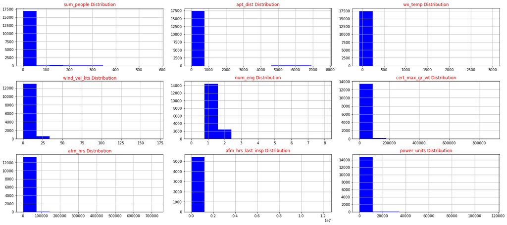

```python
def draw_histograms(dataframe, features, rows, cols):
    fig = plt.figure(figsize=(20, 20))
    for i, feature in enumerate(features):
        ax = fig.add_subplot(rows,cols,i+1)
        dataframe[feature].hist(bins = 10, ax = ax, facecolor = 'blue')
        ax.set_title(feature + " Distribution", color='red')
    fig.tight_layout()
    plt.show()

draw_histograms(AVGAS_contin.toPandas(), AVGAS_contin.toPandas().columns, 7, 3)
```

It appears as though all the variables have a huge positive skew. However, there are values that are so high that the binning for the bars is not very effective. This may be an indication of outliers so they will be identified and addressed.

Dictionaries are set and filled with values related to outlier detection for easier math in Python.

```python
quarters = dict()
iqr = dict()
lower = dict()
upper = dict()
lower_out = dict()
upper_out = dict()
total_out = dict()

for column in AVGAS_contin.columns:
    quarters[column] = AVGAS.approxQuantile(column, [0.25, 0.5, 0.75], 0)
    iqr[column] = quarters[column][2] - quarters[column][0]
    lower[column] = quarters[column][0] - (1.5 * iqr[column])
    upper[column] = quarters[column][2] + (1.5 * iqr[column])
    lower_out[column] = (AVGAS.filter(col(column) < lower[column])).count()
    upper_out[column] = (AVGAS.filter(col(column) > upper[column])).count()
    total_out[column] = lower_out[column] + upper_out[column]
```

**'sum_people' Exploration**

```python
AVGAS.describe('sum_people').show()
print('Missing values:', (AVGAS.filter(col('sum_people').isNull()).count()))
print('Percent missing:', round((AVGAS.filter(col('sum_people').isNull()).count() / AVGAS.count() * 100), 2), '%')
print('Quarters:', quarters['sum_people'])
print('Lower & upper bounds:', lower['sum_people'], ',', upper['sum_people'])
print('Lower outliers:', lower_out['sum_people'])
print('Upper outliers:', upper_out['sum_people'])
print('Percent outliers:', round((total_out['sum_people'] / AVGAS.filter(col('sum_people').isNotNull()).count() * 100), 2), '%')
```

```
+-------+------------------+
|summary|        sum_people|
+-------+------------------+
|  count|             17410|
|   mean| 5.924124066628375|
| stddev|27.648294946462894|
|    min|                 0|
|    max|               576|
+-------+------------------+

Missing values: 95
Percent missing: 0.54 %
Quarters: [1.0, 2.0, 2.0]
Lower & upper bounds: -0.5 , 3.5
Lower outliers: 0
Upper outliers: 1895
Percent outliers: 10.88 %
```

The upper bound for outliers is over 3 people involved in the accident, and about 11% are over that number. This means that most of the observations in this dataset involve accidents where there are 3 or less people involved. While 11% are outliers, it may not make sense to adjust them. The maximum number of involved people is 576. The column will be examined to see if there are other quantities of people near this value, or if the maximum is unique in how high it is.

```python
AVGAS.groupBy('sum_people').agg(col('sum_people')).sort(desc('sum_people')).show(10)
```

```
+----------+----------+
|sum_people|sum_people|
+----------+----------+
|       576|       576|
|       454|       454|
|       406|       406|
|       397|       397|
|       394|       394|
|       378|       378|
|       352|       352|
|       333|       333|
|       324|       324|
|       314|       314|
+----------+----------+
only showing top 10 rows
```

The above are all reasonable numbers of people that can be on a plane. As a result, outliers will not be changed for this variable. However, there is a small amount of missing values that must be filled. The mean will be used.

**'apt_dist' Exploration**

```python
AVGAS.describe('apt_dist').show()
print('Missing values:', (AVGAS.filter(col('apt_dist').isNull()).count()))
print('Percent missing:', round((AVGAS.filter(col('apt_dist').isNull()).count() / AVGAS.count() * 100), 2), '%')
print('Quarters:', quarters['apt_dist'])
print('Lower & upper bounds:', lower['apt_dist'], ',', upper['apt_dist'])
print('Lower outliers:', lower_out['apt_dist'])
print('Upper outliers:', upper_out['apt_dist'])
print('Percent outliers:', round((total_out['apt_dist'] / AVGAS.filter(col('apt_dist').isNotNull()).count() * 100), 2), '%')
```

```
+-------+------------------+
|summary|          apt_dist|
+-------+------------------+
|  count|             17505|
|   mean|23.554927163667525|
| stddev|360.02242746365664|
|    min|                -1|
|    max|              7671|
+-------+------------------+

Missing values: 0
Percent missing: 0.0 %
Quarters: [0.0, 0.0, 0.0]
Lower & upper bounds: 0.0 , 0.0
Lower outliers: 12
Upper outliers: 3628
Percent outliers: 20.79 %
```

Any aircraft that traveled any amount of distance from the airport is considered an outlier. Therefore, about 21% of the accidents occurred away from the airport. There appear to be 12 accidents where the aircraft moved negative distance, which should not be possible. The values for these observations will become '0'. The highest values for this variable may be too high compared to the others.

```python
AVGAS = AVGAS.withColumn('apt_dist', when(AVGAS.apt_dist < 0, 0).otherwise(col('apt_dist')))

AVGAS.select('apt_dist').sort('apt_dist', ascending = False).show(10)
```

```
+--------+
|apt_dist|
+--------+
|    7671|
|    7470|
|    6900|
|    6856|
|    6848|
|    6837|
|    6805|
|    6795|
|    6763|
|    6763|
+--------+
only showing top 10 rows
```

There are no values near the max that stick out. It is unreasonable to change any of the values that are considered outliers, so they will be kept. As fuel exhaustion seems to be a huge cause of fuel-related accidents, 'apt_dist' could be a valuable variable for prediction. After all, an aircraft needs to consume fuel and travel before it can run out of fuel. For that reason, a new binary variable will be developed, and it will have a value of '0' if 'apt_dist' is '0' and '1' if 'apt_dist' is anything higher. It may be useful for further analysis.

```python
AVGAS = AVGAS.withColumn('apt_moved',
     when(AVGAS.apt_dist > 0, 1)
    .otherwise(0))

AVGAS.groupBy('apt_moved').count().show()
```

```
+---------+-----+
|apt_moved|count|
+---------+-----+
|        1| 3628|
|        0|13877|
+---------+-----+
```

The above values for the new 'apt_moved' variable are consistent with the 'apt_dist' summary statistics.

**'wx_temp' Exploration**

```python
AVGAS.describe('wx_temp').show()
print('Missing values:', (AVGAS.filter(col('wx_temp').isNull()).count()))
print('Percent missing:', round((AVGAS.filter(col('wx_temp').isNull()).count() / AVGAS.count() * 100), 2), '%')
print('Quarters:', quarters['wx_temp'])
print('Lower & upper bounds:', lower['wx_temp'], ',', upper['wx_temp'])
print('Lower outliers:', lower_out['wx_temp'])
print('Upper outliers:', upper_out['wx_temp'])
print('Percent outliers:', round((total_out['wx_temp'] / AVGAS.filter(col('wx_temp').isNotNull()).count() * 100), 2), '%')
```

```
+-------+------------------+
|summary|           wx_temp|
+-------+------------------+
|  count|             17505|
|   mean|61.943673236218224|
| stddev|  33.5539046088555|
|    min|               -71|
|    max|              3006|
+-------+------------------+

Missing values: 0
Percent missing: 0.0 %
Quarters: [52.0, 68.0, 79.0]
Lower & upper bounds: 11.5 , 119.5
Lower outliers: 1388
Upper outliers: 36
Percent outliers: 8.13 %
```

About 92% of temperatures fall between 12 and 119 degrees Celsius. Only 36 observations have hotter temperatures than 119 degrees, and the maximum of 3006 does not seem right. Both the min and max may be indications that values are not quite right.

```python
AVGAS.select(['wx_temp', 'ev_state']).sort('wx_temp', ascending = False).show(10)
```

```
+-------+--------+
|wx_temp|ev_state|
+-------+--------+
|   3006|      CO|
|    185|      CA|
|    183|      VA|
|    180|      TX|
|    180|      NC|
|    180|      PA|
|    178|      OH|
|    176|      ID|
|    172|      NC|
|    172|    null|
+-------+--------+
only showing top 10 rows
```

```python
AVGAS.select(['wx_temp', 'ev_state']).sort('wx_temp', ascending = True).show(10)
```

```
+-------+--------+
|wx_temp|ev_state|
+-------+--------+
|    -71|      MT|
|    -54|      MO|
|    -36|    null|
|    -29|      AK|
|    -29|      AK|
|    -27|      AK|
|    -27|      AK|
|    -24|      AK|
|    -22|      AK|
|    -20|      AK|
+-------+--------+
only showing top 10 rows
```

The Alaskan temperatures make sense, but the lowest ones are in Montana and Missouri. Those, along with the state with a null value, will be replaced with the mean as well. There is a possibility that really cold temperatures could lead to fuel-related problems, and I do not want to eliminate the very real Alaskan temperatures from the dataset, so those will not be changed. There are over 1,300 outliers lower than 12 degrees Celsius, and the air can definitely get colder than that. This implies that most accidents take place when it is warmer. This could also be because there may be more flights when it is warmer.

```python
AVGAS = AVGAS.withColumn('wx_temp', when((AVGAS.wx_temp > (-30)) & (AVGAS.wx_temp <= 119), col('wx_temp')))

AVGAS.describe('wx_temp').show()
```

```
+-------+------------------+
|summary|           wx_temp|
+-------+------------------+
|  count|             17466|
|   mean|61.605633802816904|
| stddev|24.720851607245432|
|    min|               -29|
|    max|               113|
+-------+------------------+
```

**'wind_vel_kts' Exploration**

```python
AVGAS.describe('wind_vel_kts').show()
print('Missing values:', (AVGAS.filter(col('wind_vel_kts').isNull()).count()))
print('Percent missing:', round((AVGAS.filter(col('wind_vel_kts').isNull()).count() / AVGAS.count() * 100), 2), '%')
print('Quarters:', quarters['wind_vel_kts'])
print('Lower & upper bounds:', lower['wind_vel_kts'], ',', upper['wind_vel_kts'])
print('Lower outliers:', lower_out['wind_vel_kts'])
print('Upper outliers:', upper_out['wind_vel_kts'])
print('Percent outliers:', round((total_out['wind_vel_kts'] /
    AVGAS.filter(col('wind_vel_kts').isNotNull()).count() * 100), 2), '%')
```

```
+-------+-----------------+
|summary|     wind_vel_kts|
+-------+-----------------+
|  count|            13557|
|   mean|7.963118684074648|
| stddev|4.985887130064353|
|    min|                0|
|    max|              170|
+-------+-----------------+

Missing values: 3948
Percent missing: 22.55 %
Quarters: [5.0, 7.0, 10.0]
Lower & upper bounds: -2.5 , 17.5
Lower outliers: 0
Upper outliers: 489
Percent outliers: 3.61 %
```

While about 23% of wind speeds are missing, only about 4% of the values that are there are outliers. The upper bound for outliers is 17 knots, which is about 20 miles per hour.

```python
AVGAS.select('wind_vel_kts').sort('wind_vel_kts', ascending = False).show(10)
```

```
+------------+
|wind_vel_kts|
+------------+
|         170|
|         112|
|         110|
|         106|
|          97|
|          75|
|          70|
|          65|
|          50|
|          47|
+------------+
only showing top 10 rows
```

There is a huge drop in values from the highest velocity to the tenth highest velocity, from 170 knots to 47. Even though these values are the top 10 values, there are still over 479 different recordings of knots over 17, the upper bound. It is probably okay to keep the speeds lower than the top 10, as they encompass several hundred; it seems to be the fastest speeds that stick out the most. These results indicate that, generally, wind speeds are not very high in the accident data.

```python
AVGAS = AVGAS.withColumn('wind_vel_kts', when((AVGAS.wind_vel_kts < 47), col('wind_vel_kts')))
```

```python
AVGAS.describe('wind_vel_kts').show()
```

```
+-------+-----------------+
|summary|     wind_vel_kts|
+-------+-----------------+
|  count|            13547|
|   mean|7.902413818557614|
| stddev|4.355925577001242|
|    min|                0|
|    max|               46|
+-------+-----------------+
```

**'num_eng' Exploration**

```python
AVGAS.describe('num_eng').show()
print('Missing values:', (AVGAS.filter(col('num_eng').isNull()).count()))
print('Percent missing:', round((AVGAS.filter(col('num_eng').isNull()).count() / AVGAS.count() * 100), 2), '%')
print('Quarters:', quarters['num_eng'])
print('Lower & upper bounds:', lower['num_eng'], ',', upper['num_eng'])
print('Lower outliers:', lower_out['num_eng'])
print('Upper outliers:', upper_out['num_eng'])
print('Percent outliers:', round((total_out['num_eng'] /
    AVGAS.filter(col('num_eng').isNotNull()).count() * 100), 2), '%')
```

```
+-------+------------------+
|summary|           num_eng|
+-------+------------------+
|  count|             16874|
|   mean|1.1543795187862984|
| stddev|0.3875959572325808|
|    min|                 0|
|    max|                 8|
+-------+------------------+

Missing values: 631
Percent missing: 3.6 %
Quarters: [1.0, 1.0, 1.0]
Lower & upper bounds: 1.0 , 1.0
Lower outliers: 2
Upper outliers: 2501
Percent outliers: 14.83 %
```

Because there are so many aircraft with only one engine, any that have more are considered outliers. Therefore, the 15% in outliers means that 15% accident aircraft have more than one engine. There are two that have 0 engines, so those will be adjusted to 1.

```python
AVGAS = AVGAS.withColumn('num_eng', when(AVGAS.num_eng == 0, 1).otherwise(col('num_eng')))

AVGAS.select(['num_eng', 'cert_max_gr_wt']).sort('num_eng', ascending = False).show(5)
```

```
+-------+--------------+
|num_eng|cert_max_gr_wt|
+-------+--------------+
|      8|           826|
|      4|         80000|
|      4|         80000|
|      4|          null|
|      4|         80000|
+-------+--------------+
only showing top 5 rows
```

The aircraft with 8 engines seems like an outlier, especially since the weight of the aircraft is so low. It does not have many engines because it is large. The value will be removed and replaced with the mean, 1.

```python
AVGAS = AVGAS.withColumn('num_eng', when((AVGAS.num_eng > 0) & (AVGAS.num_eng < 8), col('num_eng')))
```

Similar to the 'apt_dist' variable, a binary variable will be created to indicate if an aircraft has multiple engines or not, and it may be useful in visualizing and analysis. It will be called 'multiple_eng', and it will have a '0' if it has one engine and a '1' if it has multiple.

```python
AVGAS = AVGAS.withColumn('multiple_eng',
     when(AVGAS.num_eng > 1, 1)
    .otherwise(0))

AVGAS.groupBy('multiple_eng').count().show()
```

```
+------------+-----+
|multiple_eng|count|
+------------+-----+
|           1| 2500|
|           0|15005|
+------------+-----+
```

**'cert_max_gr_wt' Exploration**

```python
AVGAS.describe('cert_max_gr_wt').show()
print('Missing values:', (AVGAS.filter(col('cert_max_gr_wt').isNull()).count()))
print('Percent missing:', round((AVGAS.filter(col('cert_max_gr_wt').isNull()).count() / AVGAS.count() * 100), 2), '%')
print('Quarters:', quarters['cert_max_gr_wt'])
print('Lower & upper bounds:', lower['cert_max_gr_wt'], ',', upper['cert_max_gr_wt'])
print('Lower outliers:', lower_out['cert_max_gr_wt'])
print('Upper outliers:', upper_out['cert_max_gr_wt'])
print('Percent outliers:', round((total_out['cert_max_gr_wt'] /
    AVGAS.filter(col('cert_max_gr_wt').isNotNull()).count() * 100), 2), '%')
```

```
+-------+-----------------+
|summary|   cert_max_gr_wt|
+-------+-----------------+
|  count|            13707|
|   mean|9485.761362807325|
| stddev|45031.99027088006|
|    min|               22|
|    max|           892450|
+-------+-----------------+

Missing values: 3798
Percent missing: 21.7 %
Quarters: [1750.0, 2500.0, 3600.0]
Lower & upper bounds: -1025.0 , 6375.0
Lower outliers: 0
Upper outliers: 1724
Percent outliers: 12.58 %
```

About 22% of the data is missing, and 13% are considered outliers, so some care needs to put into deciding on what to do with the outliers. If all the outliers are changed, then a large portion of the data in this variable would essentially function as null. The minimum value of 22 does not seem right, so that will be examined. Because the lower bound is in the negatives, a cutoff needs to be decided for what the lightest aircraft can remain.

```python
AVGAS.select('cert_max_gr_wt').sort('cert_max_gr_wt', ascending = False).show(10)
```

```
+--------------+
|cert_max_gr_wt|
+--------------+
|        892450|
|        875000|
|        875000|
|        875000|
|        870000|
|        833000|
|        800000|
|        767925|
|        767925|
|        761600|
+--------------+
only showing top 10 rows
```

The top 10 highest weights are relatively evenly spaced from each other, so none of them stick out. Due to the large amount of missing data, these values will stay as they are. Several counts will occur to determine what the minimum threshold is, however.

```python
print('Number of observations removed for each minimum threshold')
print('250:', AVGAS.filter(col('cert_max_gr_wt') < 250).count())
print('500:', AVGAS.filter(col('cert_max_gr_wt') < 500).count())
print('750:', AVGAS.filter(col('cert_max_gr_wt') < 750).count())
print('1000:', AVGAS.filter(col('cert_max_gr_wt') < 1000).count())
print('1250:', AVGAS.filter(col('cert_max_gr_wt') < 1250).count())
print('1500:', AVGAS.filter(col('cert_max_gr_wt') < 1500).count())
print('1750:', AVGAS.filter(col('cert_max_gr_wt') < 1750).count())
```

```
Number of observations removed for each minimum threshold
250: 4
500: 17
750: 123
1000: 322
1250: 1012
1500: 2140
1750: 3242
```

```python
AVGAS = AVGAS.withColumn('cert_max_gr_wt', when(AVGAS.cert_max_gr_wt > 750, col('cert_max_gr_wt')))

AVGAS.describe('cert_max_gr_wt').show()
```

```
+-------+-----------------+
|summary|   cert_max_gr_wt|
+-------+-----------------+
|  count|            13579|
|   mean|9569.521172398556|
| stddev|45235.44483388107|
|    min|              754|
|    max|           892450|
+-------+-----------------+
```

**'afm_hrs' Exploration**

```python
AVGAS.describe('afm_hrs').show()
print('Missing values:', (AVGAS.filter(col('afm_hrs').isNull()).count()))
print('Percent missing:', round((AVGAS.filter(col('afm_hrs').isNull()).count() / AVGAS.count() * 100), 2), '%')
print('Quarters:', quarters['afm_hrs'])
print('Lower & upper bounds:', lower['afm_hrs'], ',', upper['afm_hrs'])
print('Lower outliers:', lower_out['afm_hrs'])
print('Upper outliers:', upper_out['afm_hrs'])
print('Percent outliers:', round((total_out['afm_hrs'] /
    AVGAS.filter(col('afm_hrs').isNotNull()).count() * 100), 2), '%')
```

```
+-------+-----------------+
|summary|          afm_hrs|
+-------+-----------------+
|  count|            13366|
|   mean|5367.580652401616|
| stddev|12015.05378337838|
|    min|                0|
|    max|           725421|
+-------+-----------------+

Missing values: 4139
Percent missing: 23.64 %
Quarters: [1259.0, 3406.0, 5967.0]
Lower & upper bounds: -5803.0 , 13029.0
Lower outliers: 0
Upper outliers: 919
Percent outliers: 6.88 %
```

Airframe hours are an indication of how much an aircraft has been used. Things that are heavily used may be prone to problems, so it's possible that it could be a predictor for fuel-related problems. Similar to the last variable examined, there are many missing values and a lower bound in the negatives. As a result, the same approach will be taken. The top airframe hours will be examined, and a minimum threshold for hours will be decided.

```python
AVGAS.select('afm_hrs').sort('afm_hrs', ascending = False).show(10)
```

```
+-------+
|afm_hrs|
+-------+
| 725421|
| 697614|
| 197778|
| 123372|
| 120691|
| 107814|
| 105752|
| 104890|
| 103501|
|  99338|
+-------+
only showing top 10 rows
```

The first three hours, 725421, 697614, and 197778 stick out the most, so they will be adjusted. Below those numbers, the values are relatively close to each other. Again, like the last variable, there is apprehension in adjusting more outliers due to the number of missing values. Next, counts will be calculated for the number of removed observations per minimum threshold.

```python
print('Number of observations removed for each minimum threshold')
print('250:', AVGAS.filter(col('afm_hrs') < 250).count())
print('500:', AVGAS.filter(col('afm_hrs') < 500).count())
print('750:', AVGAS.filter(col('afm_hrs') < 750).count())
```

```
Number of observations removed for each minimum threshold
250: 1367
500: 2100
750: 2593
```

Even below 250 airframe hours, almost 10% of the values would be removed. It also makes sense that an aircraft can have low airframe hours at the time of an accident - it just means that it is relatively new. Therefore, a minimum will not be set.

```python
AVGAS = AVGAS.withColumn('afm_hrs', when(AVGAS.afm_hrs < 150000, col('afm_hrs')))

AVGAS.describe('afm_hrs').show()
```

```
+-------+-----------------+
|summary|          afm_hrs|
+-------+-----------------+
|  count|            13363|
|   mean|5247.494574571579|
| stddev| 8181.88305163577|
|    min|                0|
|    max|           123372|
+-------+-----------------+
```

**'afm_hrs_last_insp' Exploration**

```python
AVGAS.describe('afm_hrs_last_insp').show()
print('Missing values:', (AVGAS.filter(col('afm_hrs_last_insp').isNull()).count()))
print('Percent missing:', round((AVGAS.filter(col('afm_hrs_last_insp').isNull()).count() / AVGAS.count() * 100), 2), '%')
print('Quarters:', quarters['afm_hrs_last_insp'])
print('Lower & upper bounds:', lower['afm_hrs_last_insp'], ',', upper['afm_hrs_last_insp'])
print('Lower outliers:', lower_out['afm_hrs_last_insp'])
print('Upper outliers:', upper_out['afm_hrs_last_insp'])
print('Percent outliers:', round((total_out['afm_hrs_last_insp'] /
    AVGAS.filter(col('afm_hrs_last_insp').isNotNull()).count() * 100), 2), '%')
```

```
+-------+------------------+
|summary| afm_hrs_last_insp|
+-------+------------------+
|  count|              5417|
|   mean|2381.0804873546244|
| stddev|164974.12908083462|
|    min|               -33|
|    max|          12142020|
+-------+------------------+

Missing values: 12088
Percent missing: 69.05 %
Quarters: [10.0, 27.0, 60.0]
Lower & upper bounds: -65.0 , 135.0
Lower outliers: 0
Upper outliers: 429
Percent outliers: 7.92 %
```

**'power_units' Exploration**

The variable 'power_units' has a significant issue. It measures engine output power, but the values use two separate units of measure: horsepower (HP) and pounds of thrust (LBS), which is tracked by the 'hp_or_lbs' variable. It's not possible to convert one into the other as the velocity of the aircraft is required (the conversion equation is LBS * V / 375 = HP). Values of 'power_units' where 'hp_or_lbs' is '1' will be removed.

```python
print('Values removed:', AVGAS.filter(col('hp_or_lbs') == 1).count())

AVGAS = AVGAS.withColumn('power_units', when(AVGAS.hp_or_lbs != 1, col('power_units')))
```

```
Values removed: 542
```

As 'hp_or_lbs' was imputed with '0' (for HP), there could be values that are still in lbs, as there could have been values for 'power_units' where 'hp_or_lbs' is null. The highest values will be examined, as values for lbs tend to be higher than HP.

```python
AVGAS.describe('power_units').show()
print('Missing values:', (AVGAS.filter(col('power_units').isNull()).count()))
print('Percent missing:', round((AVGAS.filter(col('power_units').isNull()).count() / AVGAS.count() * 100), 2), '%')
print('Quarters:', quarters['power_units'])
print('Lower & upper bounds:', lower['power_units'], ',', upper['power_units'])
print('Lower outliers:', lower_out['power_units'])
print('Upper outliers:', upper_out['power_units'])
print('Percent outliers:', round((total_out['power_units'] /
    AVGAS.filter(col('power_units').isNotNull()).count() * 100), 2), '%')
```

```
+-------+------------------+
|summary|       power_units|
+-------+------------------+
|  count|             14495|
|   mean|324.05381165919283|
| stddev|1448.5079986343037|
|    min|                 0|
|    max|             85000|
+-------+------------------+

Missing values: 3010
Percent missing: 17.2 %
Quarters: [150.0, 180.0, 300.0]
Lower & upper bounds: -75.0 , 525.0
Lower outliers: 0
Upper outliers: 1719
Percent outliers: 11.86 %
```

With the significant outliers removed, clearer histograms of the continuous variables can possibly be developed.

```python
contin_vars = ['sum_people', 'apt_dist', 'wx_temp', 'wind_vel_kts', 'num_eng',
               'cert_max_gr_wt', 'afm_hrs', 'afm_hrs_last_insp', 'power_units']

for column in contin_vars:
    AVGAS = AVGAS.withColumn(column, col(column).cast('integer'))

AVGAS_contin = AVGAS.select(*contin_vars)
```

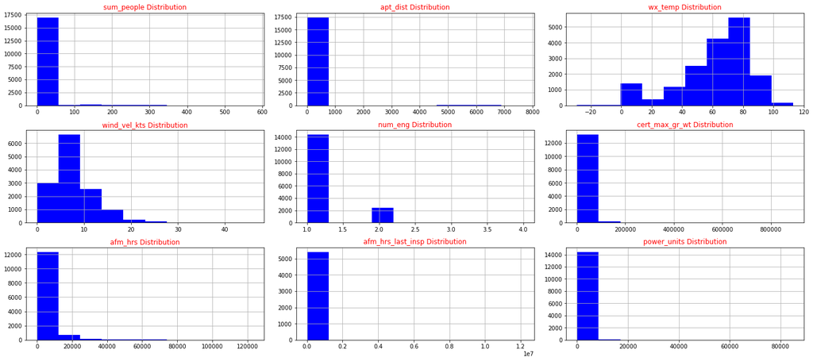

```python
def draw_histograms(dataframe, features, rows, cols):
    fig = plt.figure(figsize=(20, 20))
    for i, feature in enumerate(features):
        ax = fig.add_subplot(rows,cols,i+1)
        dataframe[feature].hist(bins = 10, ax = ax, facecolor = 'blue')
        ax.set_title(feature + " Distribution", color='red')
    fig.tight_layout()
    plt.show()

draw_histograms(AVGAS_contin.toPandas(), AVGAS_contin.toPandas().columns, 7, 3)
```

Some of the histograms more clearly show positive skew in their distributions. For the variables that have missing values, the mean is imputed.

```python
mean_impute = ['sum_people', 'apt_moved', 'wx_temp', 'wind_vel_kts', 'num_eng', 'multiple_eng',
               'cert_max_gr_wt', 'afm_hrs', 'afm_hrs_last_insp', 'power_units']

imputer = Imputer(
    inputCols = mean_impute,
    outputCols = ['{}'.format(c) for c in mean_impute]
    ).setStrategy('mean')

AVGAS = imputer.fit(AVGAS).transform(AVGAS)
```

#### Categorical Variables

Next, categorical variables will be examined.

```python
category_vars = ['ev_state', 'ev_highest_injury', 'light_cond', 'acft_fire', 'acft_expl',
                 'far_part', 'damage', 'type_fly', 'eng_type']

AVGAS_category = AVGAS.select(*category_vars)
```

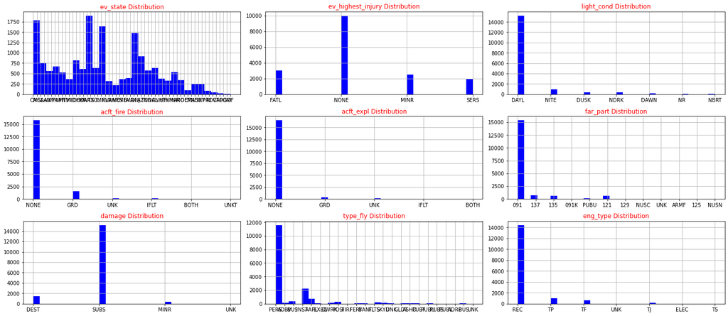

```python
import matplotlib.pyplot as plt
%matplotlib inline

def draw_histograms(dataframe, features, rows, cols):
    fig = plt.figure(figsize=(20, 20))
    for i, feature in enumerate(features):
        ax = fig.add_subplot(rows,cols,i+1)
        dataframe[feature].hist(bins = 30, ax = ax, facecolor = 'blue')
        ax.set_title(feature + " Distribution", color='red')
    fig.tight_layout()
    plt.show()

draw_histograms(AVGAS_category.toPandas(), AVGAS_category.toPandas().columns, 7, 3)
```

Many of the variables have values of 'UNK', these values will be replaced with empty space to make missing values consistent with each other.

```python
AVGAS = AVGAS.withColumn('acft_fire', when((col('acft_fire') != 'UNK') & (col('acft_fire') != 'UNKT'), col('acft_fire')))
AVGAS = AVGAS.withColumn('acft_expl', when(col('acft_expl') != 'UNK', col('acft_expl')))
AVGAS = AVGAS.withColumn('far_part', when((col('far_part') != 'UNK') & (col('far_part') != '091K'), col('far_part')))
AVGAS = AVGAS.withColumn('damage', when(col('damage') != 'UNK', col('damage')))
AVGAS = AVGAS.withColumn('type_fly', when((col('type_fly') != 'UNK') & (col('type_fly') != 'UNK '), col('type_fly')))
AVGAS = AVGAS.withColumn('eng_type', when(col('eng_type') != 'UNK', col('eng_type')))
```

Splitting the dates of the accidents into months or quarters may provide more meaningful categories for predictive modeling.

```python
from pyspark.sql.functions import month, quarter

AVGAS = AVGAS.withColumn('ev_month', month(AVGAS.ev_date))
AVGAS = AVGAS.withColumn('ev_quarter', quarter(AVGAS.ev_date))

AVGAS = AVGAS.withColumn('ev_month', AVGAS.ev_month.cast('string'))
AVGAS = AVGAS.withColumn('ev_quarter', AVGAS.ev_quarter.cast('string'))
```

Additionally, there are potentially too many states and territories to be useful when converting the categorical variables into dummy variables. Using the regions the FAA splits the U.S. by, a new variable can be created to organize the states and territories into subsets.

```python
New_England_list = ['CT', 'ME', 'MA', 'NH', 'RI', 'VT']
Eastern_list = ['DE', 'MD', 'NJ', 'NY', 'PA', 'VA', 'DC', 'WV']
Southern_list = ['AL', 'FL', 'GA', 'KY', 'MS', 'NC', 'PR', 'SC', 'TN', 'VI']
Great_Lakes_list = ['IL', 'IN', 'MI', 'MN', 'ND', 'OH', 'SD', 'WI']
Central_list = ['IA', 'KS', 'MO', 'NE']
Southwest_list = ['AR', 'LA', 'NM', 'OK', 'TX']
Northwest_Mountain_list = ['CO', 'ID', 'MT', 'OR', 'UT', 'WA', 'WY']
Western_Pacific_list = ['AS', 'AZ', 'CA', 'MP', 'GU', 'HI', 'NV']

AVGAS = AVGAS.withColumn('ev_region',
     when(AVGAS.ev_state.isin(New_England_list), 'NEW ENGLAND')
    .when(AVGAS.ev_state.isin(Eastern_list), 'EASTERN')
    .when(AVGAS.ev_state.isin(Southern_list), 'SOUTHERN')
    .when(AVGAS.ev_state.isin(Great_Lakes_list), 'GREAT LAKES')
    .when(AVGAS.ev_state.isin(Central_list), 'CENTRAL')
    .when(AVGAS.ev_state.isin(Southwest_list), 'SOUTHWEST')
    .when(AVGAS.ev_state.isin(Northwest_Mountain_list), 'NORTHWEST MOUNTAIN')
    .when(AVGAS.ev_state.isin(Western_Pacific_list), 'WESTERN PACIFIC')
    .when(AVGAS.ev_state == 'AK', 'ALASKAN'))
```

Adjusted histograms featuring some of the new variables will be displayed.

```python
category_vars = ['ev_region', 'ev_highest_injury', 'light_cond', 'acft_fire', 'acft_expl',
                 'far_part', 'damage', 'type_fly', 'eng_type']

AVGAS_category = AVGAS.select(*category_vars)
```

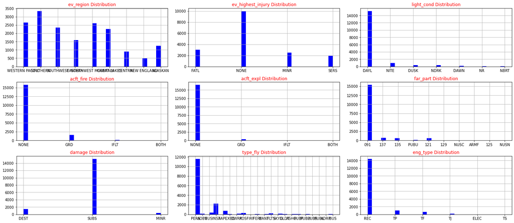

```python
import matplotlib.pyplot as plt
%matplotlib inline

def draw_histograms(dataframe, features, rows, cols):
    fig = plt.figure(figsize=(20, 20))
    for i, feature in enumerate(features):
        ax = fig.add_subplot(rows,cols,i+1)
        dataframe[feature].hist(bins = 30, ax = ax, facecolor = 'blue')
        ax.set_title(feature + " Distribution", color='red')
    fig.tight_layout()
    plt.show()

draw_histograms(AVGAS_category.toPandas(), AVGAS_category.toPandas().columns, 7, 3)
```

Missing values are examined to determine if each of these variables are worth keeping for modeling.

```python
print('Missing values percentages:')
print('ev_region:', round((AVGAS.filter(col('ev_region').isNull()).count() / AVGAS.count() * 100), 2), '%')
print('ev_highest_injury:', round((AVGAS.filter(col('ev_highest_injury').isNull()).count() / AVGAS.count() * 100), 2), '%')
print('light_cond:', round((AVGAS.filter(col('light_cond').isNull()).count() / AVGAS.count() * 100), 2), '%')
print('acft_fire:', round((AVGAS.filter(col('acft_fire').isNull()).count() / AVGAS.count() * 100), 2), '%')
print('acft_expl:', round((AVGAS.filter(col('acft_expl').isNull()).count() / AVGAS.count() * 100), 2), '%')
print('far_part:', round((AVGAS.filter(col('far_part').isNull()).count() / AVGAS.count() * 100), 2), '%')
print('damage:', round((AVGAS.filter(col('damage').isNull()).count() / AVGAS.count() * 100), 2), '%')
print('type_fly:', round((AVGAS.filter(col('type_fly').isNull()).count() / AVGAS.count() * 100), 2), '%')
print('eng_type:', round((AVGAS.filter(col('eng_type').isNull()).count() / AVGAS.count() * 100), 2), '%')
```

```
Missing values percentages:
ev_region: 0.42 %
ev_highest_injury: 0.54 %
light_cond: 2.2 %
acft_fire: 0.46 %
acft_expl: 3.82 %
far_part: 0.16 %
damage: 2.66 %
type_fly: 7.26 %
eng_type: 7.14 %
```

None of the potentially relevant categorical variables have too many missing values. As modeling with the scikit learn package requires zero missing values, they will be filled with the mode.

```python
AVGAS = AVGAS.na.fill(value = 'SOUTHERN', subset = 'ev_region')
AVGAS = AVGAS.na.fill(value = 'NONE', subset = 'ev_highest_injury')
AVGAS = AVGAS.na.fill(value = 'DAYL', subset = 'light_cond')
AVGAS = AVGAS.na.fill(value = 'NONE', subset = 'acft_fire')
AVGAS = AVGAS.na.fill(value = 'NONE', subset = 'acft_expl')
AVGAS = AVGAS.na.fill(value = '091', subset = 'far_part')
AVGAS = AVGAS.na.fill(value = 'SUBS', subset = 'damage')
AVGAS = AVGAS.na.fill(value = 'PERS', subset = 'type_fly')
AVGAS = AVGAS.na.fill(value = '091', subset = 'far_part')
AVGAS = AVGAS.na.fill(value = 'REC', subset = 'eng_type')
```

## Word Clouds

Word clouds based on the 'narr_cause' variable can provide a lot of insight into the nature of the fuel-related and engine-related problems captured by the 'fuel_rel' and 'eng_rel' variables.

```python
AVGASp = AVGAS.toPandas()
```

```python
import numpy as np
import pandas as pd
from os import path
from PIL import Image
#conda install -c https://conda.anaconda.org/conda-forge wordcloud
from wordcloud import WordCloud, STOPWORDS, ImageColorGenerator

import matplotlib.pyplot as plt
%matplotlib inline
```

Word cloud for fuel-related accidents:

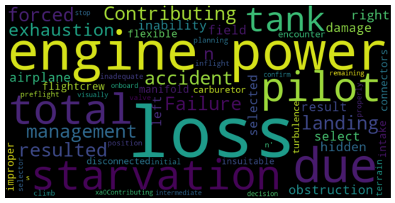

```python
fuel_text = AVGASp[AVGASp['fuel_rel'] == 1]['narr_cause'].values
stopwords = set(STOPWORDS)
stopwords.update(['fuel'])

fuel_wordcloud = WordCloud(stopwords = stopwords, width = 800, height = 400).generate(str(fuel_text))

# Display the generated image:
plt.figure(figsize=(10,5))
plt.imshow(fuel_wordcloud, interpolation = 'bilinear')
plt.axis('off')
plt.show()
```

There are several key observations made from this visualization and its largest words. First, the word 'pilot' is among the largest. Typically, the pilot is mentioned in the narrative cause when the pilot made some type of error or the problem was due to negligence. The word 'loss' and the phrase 'engine power' go hand-in-hand; the phrase 'loss of engine power' appears frequently in fuel-related accidents, indicating that these types of issues typically cause the engine to stop working. The words 'exhaustion' and 'starvation' also stick out, and these represent different types of fuel difficulties in aircraft.

```python
print('Starvation:',
      round((AVGAS.filter((col('fuel_rel') == '1') & (col('narr_cause').contains('starvation'))).count() /
             AVGAS.filter(col('fuel_rel') == '1').count() * 100), 2),
      '% of fuel-related accidents')
print('Exhaustion:',
      round((AVGAS.filter((col('fuel_rel') == '1') & (col('narr_cause').contains('exhaustion'))).count() /
             AVGAS.filter(col('fuel_rel') == '1').count() * 100), 2),
      '% of fuel-related accidents')
```

```
Starvation: 33.01 % of fuel-related accidents
Exhaustion: 32.59 % of fuel-related accidents
```

Word cloud for engine-related accidents:

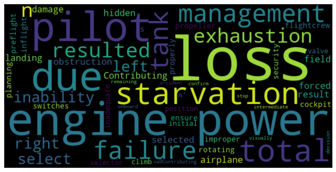

```python
eng_text = AVGASp[AVGASp['eng_rel'] == 1]['narr_cause'].values
stopwords = set(STOPWORDS)
stopwords.update(['fuel'])

fuel_wordcloud = WordCloud(stopwords = stopwords, width = 800, height = 400).generate(str(eng_text))

# Display the generated image:
plt.figure(figsize=(10, 5))
plt.imshow(fuel_wordcloud, interpolation = 'bilinear')
plt.axis('off')
plt.show()
```

Despite 'eng_rel' having nearly double the amount of values than 'fuel_rel', the word cloud looks largely the same. This suggests that both fuel and engine issues have the same, or nearly the same causes dictated in the 'narr_cause' variable. Therefore, expanding the number of issues with 'eng_rel' may have a positive effect on model development as there are more cases in the minority classification.

```python
print('Starvation:',
      round((AVGAS.filter((col('eng_rel') == '1') & (col('narr_cause').contains('starvation'))).count() /
             AVGAS.filter(col('eng_rel') == '1').count() * 100), 2),
      '% of engine-related accidents')
print('Exhaustion:',
      round((AVGAS.filter((col('eng_rel') == '1') & (col('narr_cause').contains('exhaustion'))).count() /
             AVGAS.filter(col('eng_rel') == '1').count() * 100), 2),
      '% of engine-related accidents')
```

```
Starvation: 21.01 % of engine-related accidents
Exhaustion: 17.92 % of engine-related accidents
```

## Predictive Modeling

Predictive modeling will be done using the 'scikit-learn' package in Python. Three different predictive models will be developed for each dependent variable: a decision tree, a logistic regression, and a random forest. The decision tree and logistic regression can be compared as different simple models, while the decision tree and random forest can be compared as a simple and complex version of the same core idea.

```python
AVGASm = AVGAS
```

#### Model Setup

Variables for modeling are chosen.

```python
for_model = ['fuel_rel', 'eng_rel', 'target', 'ev_type', 'homebuilt', 'hp_or_lbs', 'carb_fuel_injection',
             'multiple_eng', 'apt_moved', 'sum_people', 'apt_dist', 'wx_temp', 'wind_vel_kts', 'num_eng',
             'cert_max_gr_wt', 'afm_hrs', 'afm_hrs_last_insp', 'power_units', 'ev_quarter', 'ev_region',
             'ev_highest_injury', 'light_cond', 'acft_fire', 'acft_expl', 'far_part', 'damage', 'type_fly',
             'eng_type']

AVGASm = AVGASm[for_model]
```

### Checking variables

```python
# now let's see how many categorical and numerical features we have:
cat_cols = [item[0] for item in AVGASm.dtypes if item[1].startswith('string')]
num_cols = [item[0] for item in AVGASm.dtypes if item[1].startswith('int')]

# Removing dependent variables from columns so they're not included in modeling
num_cols.remove('fuel_rel')
num_cols.remove('eng_rel')

print(str(len(cat_cols)) + ' categorical features')
print(str(len(num_cols)) + ' numerical features')
```

```
10 categorical features
16 numerical features
```

### Addressing Imbalanced Data

The data is checked for imbalance.

```python
AVGASm.groupby('fuel_rel').count().toPandas()
```

|  | fuel_rel | count |
| --- | --- | --- |
| 0 | 1 | 1651 |
| 1 | 0 | 15854 |

```python
AVGASm.groupby('eng_rel').count().toPandas()
```

|  | eng_rel | count |
| --- | --- | --- |
| 0 | 1 | 3070 |
| 1 | 0 | 14435 |

Out of the 17,505 observations, 1651 (9.4%) are fuel-related and 3070 (17.5%) are engine-related. Weights will be assigned for predictive modeling. It will be done by adding 'balanced' to the training of the models.

### Dummy Variables

The dataframe is converted to pandas, and dummy variables are developed for each involved categorical variable.

```python
AVGASm = AVGASm.toPandas()
```

```python
var_dummies = pd.get_dummies(AVGASm, columns = cat_cols)
fuel_label = var_dummies['fuel_rel']
eng_label = var_dummies['eng_rel']
# Dropping the dependent variables from the features
feature_cols = var_dummies.drop(['fuel_rel', 'eng_rel'], axis=1)

print('Total number of feature columns:', len(var_dummies.columns.tolist()))
```

```
Total number of feature columns: 90
```

### Train & Test Sets

There are two different labels, one for each dependent variable. To see the results for the other dependent variable, replace the 'y' value in the following code with 'fuel_label' or 'eng_label' and rerun the rest of the code.

```python
X = feature_cols
y = fuel_label

from sklearn.model_selection import train_test_split
X_train, X_test, y_train, y_test = train_test_split(X, y, test_size=0.3, random_state=1) # 70% training and 30% test

print ("Number of records in the training set: " + str(y_train.count()))
print ("Number of records in the test set: " + str(y_test.count()))
```

```
Number of records in the training set: 12253
Number of records in the test set: 5252
```

```python
from sklearn import metrics
from sklearn.metrics import classification_report, confusion_matrix
```

### Decision Tree Model

This is the first developed model.

```python
from sklearn.tree import DecisionTreeClassifier

dcst = DecisionTreeClassifier(max_depth= 5, min_samples_split = 5, class_weight='balanced')
clf = dcst.fit(X_train,y_train)
y_pred_train=dcst.predict(X_train)
y_pred = dcst.predict(X_test)
```

```python
print('Confusion matrix on train:')
print(confusion_matrix(y_train, y_pred_train))
print('\n')
print('Confusion matrix on test:')
print(confusion_matrix(y_test, y_pred))
print('\n')
print(classification_report(y_train, y_pred_train))
print('\n')
print(classification_report(y_test, y_pred))
```

```
Confusion matrix on train:
[[7348 3712]
 [ 397  796]]


Confusion matrix on test:
[[3213 1581]
 [ 154  304]]


              precision    recall  f1-score   support

           0       0.95      0.66      0.78     11060
           1       0.18      0.67      0.28      1193

    accuracy                           0.66     12253
   macro avg       0.56      0.67      0.53     12253
weighted avg       0.87      0.66      0.73     12253



              precision    recall  f1-score   support

           0       0.95      0.67      0.79      4794
           1       0.16      0.66      0.26       458

    accuracy                           0.67      5252
   macro avg       0.56      0.67      0.52      5252
weighted avg       0.89      0.67      0.74      5252
```

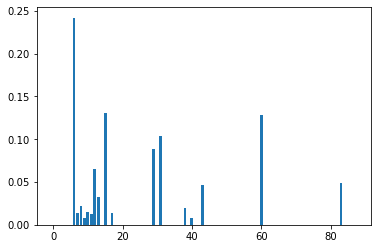

```python
importance = dcst.feature_importances_

from matplotlib import pyplot
pyplot.bar([x for x in range(len(importance))], importance)
pyplot.show()
```

```python
importance_dcst = pd.Series(dcst.feature_importances_, index=X.columns)

#pd.set_option('display.float_format', lambda x: '%.10f' % x) #Needed to suppress scientific notation for readibility
print(importance_dcst.to_string())
```

```
target                          0.000000
ev_type                         0.000000
homebuilt                       0.000000
hp_or_lbs                       0.000000
carb_fuel_injection             0.000000
multiple_eng                    0.000000
apt_moved                       0.241960
sum_people                      0.014212
apt_dist                        0.022317
wx_temp                         0.008093
wind_vel_kts                    0.015156
num_eng                         0.012718
cert_max_gr_wt                  0.065703
afm_hrs                         0.032730
afm_hrs_last_insp               0.000000
power_units                     0.130222
ev_quarter_1                    0.000000
ev_quarter_2                    0.013908
ev_quarter_3                    0.000000
ev_quarter_4                    0.000000
ev_region_ALASKAN               0.000000
ev_region_CENTRAL               0.000000
ev_region_EASTERN               0.000000
ev_region_GREAT LAKES           0.000000
ev_region_NEW ENGLAND           0.000000
ev_region_NORTHWEST MOUNTAIN    0.000000
ev_region_SOUTHERN              0.000000
ev_region_SOUTHWEST             0.000000
ev_region_WESTERN PACIFIC       0.000000
ev_highest_injury_FATL          0.088041
ev_highest_injury_MINR          0.000000
ev_highest_injury_NONE          0.103371
ev_highest_injury_SERS          0.000000
light_cond_DAWN                 0.000000
light_cond_DAYL                 0.000000
light_cond_DUSK                 0.000000
light_cond_NBRT                 0.000000
light_cond_NDRK                 0.000000
light_cond_NITE                 0.019704
light_cond_NR                   0.000000
```

[output cut: 33 more lines]

```
type_fly_INST                   0.000000
type_fly_OWRK                   0.000000
type_fly_PERS                   0.000000
type_fly_POSI                   0.000000
type_fly_PUBF                   0.000000
type_fly_PUBL                   0.000000
type_fly_PUBS                   0.000000
type_fly_PUBU                   0.000000
type_fly_SKYD                   0.000000
eng_type_ELEC                   0.000000
eng_type_REC                    0.049192
eng_type_TF                     0.000000
eng_type_TJ                     0.000000
eng_type_TP                     0.000000
eng_type_TS                     0.000000
```

### Logistic Regression Model

This is the second developed model.

```python
from sklearn.linear_model import LogisticRegression

logreg = LogisticRegression(class_weight = 'balanced', max_iter = 100)
logreg.fit(X_train, y_train)

y_pred_train=logreg.predict(X_train)
y_pred=logreg.predict(X_test)
```

```python
print('Confusion matrix on train:')
print(confusion_matrix(y_train, y_pred_train))
print('\n')
print('Confusion matrix on test:')
print(confusion_matrix(y_test, y_pred))
print('\n')
print(classification_report(y_train, y_pred_train))
print('\n')
print(classification_report(y_test, y_pred))
```

```
Confusion matrix on train:
[[6224 4836]
 [ 517  676]]


Confusion matrix on test:
[[2747 2047]
 [ 192  266]]


              precision    recall  f1-score   support

           0       0.92      0.56      0.70     11060
           1       0.12      0.57      0.20      1193

    accuracy                           0.56     12253
   macro avg       0.52      0.56      0.45     12253
weighted avg       0.85      0.56      0.65     12253



              precision    recall  f1-score   support

           0       0.93      0.57      0.71      4794
           1       0.12      0.58      0.19       458

    accuracy                           0.57      5252
   macro avg       0.52      0.58      0.45      5252
weighted avg       0.86      0.57      0.67      5252
```

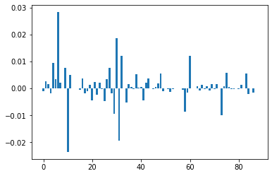

```python
importance = logreg.coef_[0]

pyplot.bar([x for x in range(len(importance))], importance)
pyplot.show()
```

```python
importance_list = pd.Series(logreg.coef_[0], index=X.columns)
print(importance_list)
```

```
target                -0.001057
ev_type                0.002764
homebuilt              0.001592
hp_or_lbs             -0.001698
carb_fuel_injection    0.009385
                         ...
eng_type_REC           0.005633
eng_type_TF           -0.002001
eng_type_TJ           -0.000053
eng_type_TP           -0.001443
eng_type_TS           -0.000015
Length: 88, dtype: float64
```

### Random Forest Model

This is the third developed model.

```python
from sklearn.ensemble import RandomForestClassifier

ranfor = RandomForestClassifier(class_weight='balanced', max_depth= 5, min_samples_split=5)
ranfor.fit(X_train, y_train)
y_pred_train=ranfor.predict(X_train)
y_pred=ranfor.predict(X_test)
```

```python
print('Confusion matrix on train:')
print(confusion_matrix(y_train, y_pred_train))
print('\n')
print('Confusion matrix on test:')
print(confusion_matrix(y_test, y_pred))
print('\n')
print(classification_report(y_train, y_pred_train))
print('\n')
print(classification_report(y_test, y_pred))
```

```
Confusion matrix on train:
[[7893 3167]
 [ 432  761]]


Confusion matrix on test:
[[3399 1395]
 [ 160  298]]


              precision    recall  f1-score   support

           0       0.95      0.71      0.81     11060
           1       0.19      0.64      0.30      1193

    accuracy                           0.71     12253
   macro avg       0.57      0.68      0.56     12253
weighted avg       0.87      0.71      0.76     12253



              precision    recall  f1-score   support

           0       0.96      0.71      0.81      4794
           1       0.18      0.65      0.28       458

    accuracy                           0.70      5252
   macro avg       0.57      0.68      0.55      5252
weighted avg       0.89      0.70      0.77      5252
```

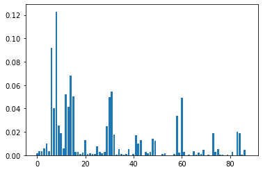

```python
importance = ranfor.feature_importances_

pyplot.bar([x for x in range(len(importance))], importance)
pyplot.show()
```

```python
importance_dcst = pd.Series(dcst.feature_importances_, index = X.columns)

print(importance_dcst.to_string())
```

```
target                          0.000000
ev_type                         0.000000
homebuilt                       0.000000
hp_or_lbs                       0.000000
carb_fuel_injection             0.000000
multiple_eng                    0.000000
apt_moved                       0.241960
sum_people                      0.014212
apt_dist                        0.022317
wx_temp                         0.008093
wind_vel_kts                    0.015156
num_eng                         0.012718
cert_max_gr_wt                  0.065703
afm_hrs                         0.032730
afm_hrs_last_insp               0.000000
power_units                     0.130222
ev_quarter_1                    0.000000
ev_quarter_2                    0.013908
ev_quarter_3                    0.000000
ev_quarter_4                    0.000000
ev_region_ALASKAN               0.000000
ev_region_CENTRAL               0.000000
ev_region_EASTERN               0.000000
ev_region_GREAT LAKES           0.000000
ev_region_NEW ENGLAND           0.000000
ev_region_NORTHWEST MOUNTAIN    0.000000
ev_region_SOUTHERN              0.000000
ev_region_SOUTHWEST             0.000000
ev_region_WESTERN PACIFIC       0.000000
ev_highest_injury_FATL          0.088041
ev_highest_injury_MINR          0.000000
ev_highest_injury_NONE          0.103371
ev_highest_injury_SERS          0.000000
light_cond_DAWN                 0.000000
light_cond_DAYL                 0.000000
light_cond_DUSK                 0.000000
light_cond_NBRT                 0.000000
light_cond_NDRK                 0.000000
light_cond_NITE                 0.019704
light_cond_NR                   0.000000
```

[output cut: 33 more lines]

```
type_fly_INST                   0.000000
type_fly_OWRK                   0.000000
type_fly_PERS                   0.000000
type_fly_POSI                   0.000000
type_fly_PUBF                   0.000000
type_fly_PUBL                   0.000000
type_fly_PUBS                   0.000000
type_fly_PUBU                   0.000000
type_fly_SKYD                   0.000000
eng_type_ELEC                   0.000000
eng_type_REC                    0.049192
eng_type_TF                     0.000000
eng_type_TJ                     0.000000
eng_type_TP                     0.000000
eng_type_TS                     0.000000
```

This is the end of the project! Analyses into the results of the predictive models are present in the paper report and presentation.